# EP03

Equipo 01

08-10-2026

# Contexto

Una exportadora compra cerezas a dos huertos, uno con riego tradicional y otro con riego tecnificado. Por los registros de temporadas anteriores, se sabe que el calibre (el diámetro) de las cerezas sigue una distribución normal con una desviación estándar de 2 mm. El jefe de calidad quiere comprobar que el calibre medio es de 28 mm, y para eso va a medir 100 cerezas, 50 de cada huerto. Además, cree que el huerto tecnificado tiene más cerezas de calibre exportable que el tradicional.

### Lectura de datos

# Pregunta 1

El jefe de calidad rechazará que el calibre medio es 28 mm si la media de la muestra es menor que 27,6 mm o mayor que 28,4 mm. Supongan que el verdadero calibre medio es 28,5 mm. Hagan un gráfico con las dos distribuciones muestrales, la hipotética y la verdadera, y marquen y calculen α y β. ¿Qué significa, para la exportadora, cometer un error de tipo II en este caso?

### Pregunta de investigación

### Datos

mu0 = 28 mua = 28.5 n = 100 sigma = 2 de = sigma/sqrt(n) alpha = 0.05 cotasup = 28.4 cotainf = 27.6

```r
mu0 = 28
mua = 28.5
n = 100
sigma = 2
de = sigma/sqrt(n)
alpha = 0.05
cotasup = 28.4
cotainf = 27.6

alpha =  pnorm(cotainf, mean = mu0, sd = de) + (1-pnorm(cotasup, mean = mu0, sd = de))

beta = pnorm(cotasup, mean = mua, sd = de) - pnorm(cotainf, mean = mua, sd = de)

cat("el valor de alpha es", round(alpha,3), "\n")
```

```
## el valor de alpha es 0.046
```

```r
cat("el valor de beta es", round(beta,3))
```

```
## el valor de beta es 0.309
```

### Formulación de hipótesis

### Grafico

```r
library(ggplot2)

mu_0 <- 28
mu_a <- 28.5
sigma <- 2
n <- 100
SE <- sigma / sqrt(n)
c_inf <- 27.6
c_sup <- 28.4

# Cálculo de alfa y beta
alfa <- pnorm(c_inf, mean = mu_0, sd = SE) + (1 - pnorm(c_sup, mean = mu_0, sd = SE))
beta <- pnorm(c_sup, mean = mu_a, sd = SE) - pnorm(c_inf, mean = mu_a, sd = SE)

cat("El valor de alfa (α) es:", round(alfa, 4), "\n")
```

```
## El valor de alfa (α) es: 0.0455
```

```r
cat("El valor de beta (β) es:", round(beta, 4), "\n")
```

```
## El valor de beta (β) es: 0.3085
```

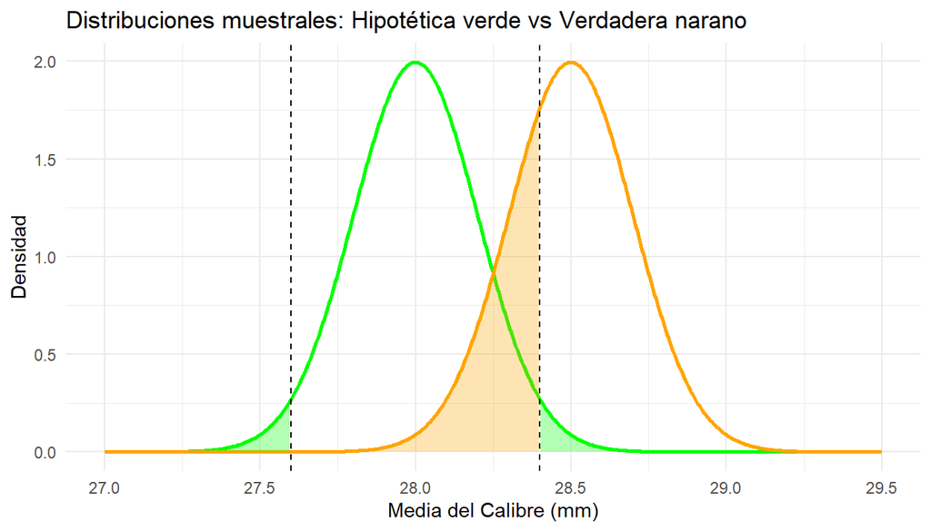

```r
# Gráfico
x_vals <- seq(27, 29.5, length.out = 500)
df_plot <- data.frame(
  x = x_vals,
  y_H0 = dnorm(x_vals, mean = mu_0, sd = SE),
  y_Ha = dnorm(x_vals, mean = mu_a, sd = SE)
)

ggplot(df_plot, aes(x = x)) +
  # Distribución H0
  geom_line(aes(y = y_H0), color = "green", size = 1) +
  # Distribución Ha
  geom_line(aes(y = y_Ha), color = "orange", size = 1) +
  # area Alfa (bajo H0, fuera de los valores críticos)
  geom_area(data = subset(df_plot, x <= c_inf), aes(y = y_H0), fill = "green", alpha = 0.3) +
  geom_area(data = subset(df_plot, x >= c_sup), aes(y = y_H0), fill = "green", alpha = 0.3) +
  # area Beta (bajo Ha, entre los valores críticos)
  geom_area(data = subset(df_plot, x >= c_inf & x <= c_sup), aes(y = y_Ha), fill = "orange", alpha = 0.3) +
  geom_vline(xintercept = c(c_inf, c_sup), linetype = "dashed") +
  labs(title = "Distribuciones muestrales: Hipotética verde vs Verdadera narano",
       x = "Media del Calibre (mm)", y = "Densidad") +
  theme_minimal()
```

### Conclusión

# Pregunta 2

### Pregunta de investigación

### Datos

### Formulación de hipótesis

### Estadístico de interés

### Remuestreo

### Conclusión

# Pregunta 3

Si el verdadero calibre medio fuera 28,5 mm, ¿cuántas cerezas habría que medir para tener un poder de 0,8 con α = 0,05?

### Pregunta de investigación

### Datos

mu0 = 28 mua = 28.5 sigma = 2 pwr = 1 - beta {0.8} de = sigma/sqrt(n) alpha = 0.05 cotasup = 28.4 cotainf = 27.6

### Formulación de hipótesis

### Calculo

```r
library(pwr)

mu0 = 28
mua = 28.5
sigma = 2
dCohen = (mua-mu0)/sigma
power = 0.8
beta = 1-power

res2 <- pwr.norm.test(d = dCohen,n= NULL, sig.level = 0.05, power = power, alternative = "two.sided")
print(res2)
```

```
##
##      Mean power calculation for normal distribution with known variance
##
##               d = 0.25
##               n = 125.5818
##       sig.level = 0.05
##           power = 0.8
##     alternative = two.sided
```

### Remuestreo

### Conclusión

# Pregunta 4

## Pregunta de investigación

## Datos

## Formulación de hipótesis

## Estadístico de interés

## Remuestreo

## Conclusión

# Referencias

Jara, J. L., & Köhler, J. (s. f.). Inferencia y modelos estadísticos [Perusall].